# Maps Tutorial

Olivia Bryant

2023-10-18

## Maps Tutorial

For this tutorial, we need to use several different packages.

To install each of the packages click Tools > Install Packages. You only have to install the package once.

### Plotting Points on a Map

In order to plot the locations of the homeless GPs on the map, you’ll need to create a CSV file with the latitude and longitude coordinates in. You can use get the coordinates by searching each of the GP surgeries and then right-clicking on the point on the map.

For this tutorial, we will be plotting the locations of English cathedrals on a map.

Firstly, we want to load the data:

```r
cathedrals <- read.csv("english_cathedrals_latlong.csv")
cathedrals
```

```
##                                                           name      LAT
## 1                          St Paul's Cathedral, London, the UK 51.51361
## 2             St Giles’ Cathedral, Edinburgh, Scotland, the UK 55.94944
## 3                                   Truro Cathedral, Truro, UK 50.26411
## 4                           Lichfield Cathedral, Lichfield, UK 52.68549
## 5               Cathedral House, Mount Pleasant, Liverpool, UK 53.40492
## 6                  Coventry Cathedral, Priory St, Coventry, UK 52.40831
## 7                              Cathedral House, Canterbury, UK 51.27980
## 8  Church of England Cathedral of the Diocese of Liverpool, UK 53.39749
## 9                      Norwich Cathedral, Norwich, Norfolk, UK 52.63119
## 10                             St Paul's Cathedral, London, UK 51.51324
## 11                      Salisbury Cathedral, Salisbury, the UK 51.06517
## 12                              Lincoln Cathedral, Lincoln, UK 53.23445
## 13                        Winchester Cathedral, Winchester, UK 51.06065
## 14              Westminster Cathedral, Westminster, London, UK 51.49628
```

[output cut: 17 more lines]

Let’s start by plotting a map of the UK.

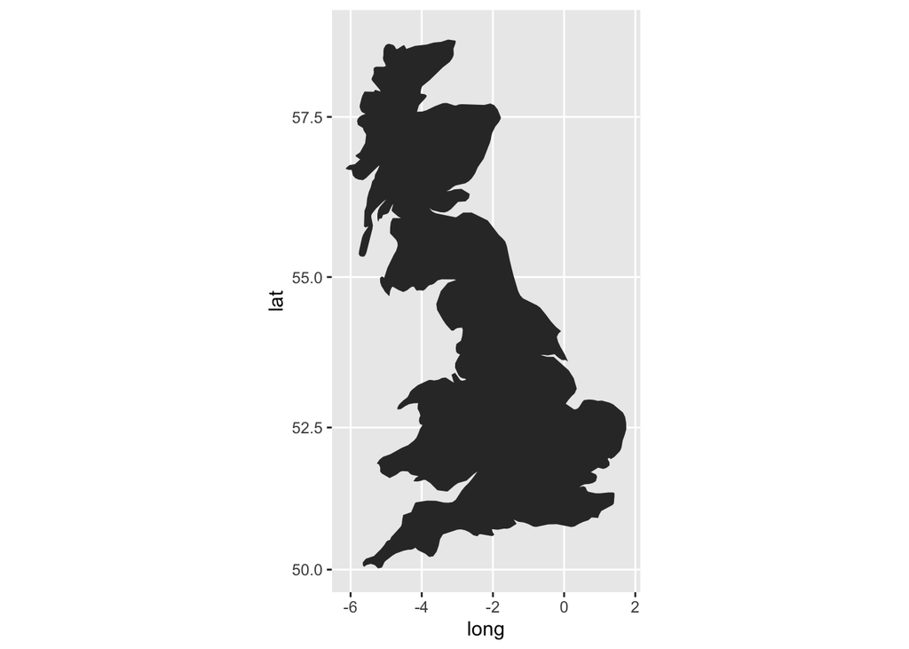

```r
# filters the map object to just look at Great Britain
UK <- map_data(map = "world", region = "UK") %>%
  filter(subregion == "Great Britain")

ggplot(data = UK, aes(x = long, y = lat, group = group)) +
  geom_polygon() +
  coord_map()
```

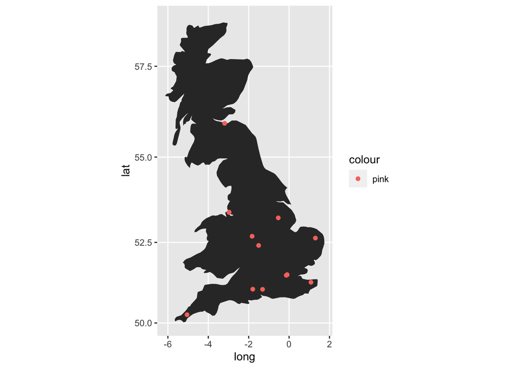

```r
cathedrals_map <- ggplot(data = UK, aes(x = long, y = lat)) +
  geom_polygon() +
  coord_map() +
  geom_point(data = cathedrals,
             aes(x = LONG,
                 y = LAT,
                 color = "pink"))

cathedrals_map
```

We probably don’t want to show the coordinates or the legend and as with any figure, we should add a title and the source.

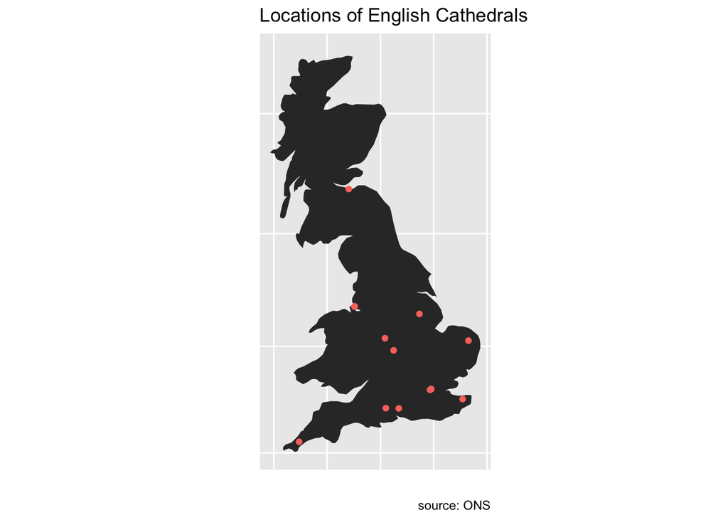

```r
cathedrals_map <- ggplot(data = UK, aes(x = long, y = lat)) +
  geom_polygon() +
  coord_map() +
  geom_point(data = cathedrals,
             aes(x = LONG,
                 y = LAT,
                 color = "pink")) +
  theme(legend.position="none",
        axis.text.x=element_blank(),
        axis.ticks.x=element_blank(),
        axis.text.y=element_blank(),
        axis.ticks.y=element_blank()) +
  labs(x = "",
       y = "",
       title = "Locations of English Cathedrals",
       caption= "source: ONS")

cathedrals_map
```

For more information on how to adjust the styles of R plots in ggplot, look at https://ggplot2.tidyverse.org/reference/theme.html

Finally, we can save the plot in our desired size.

```r
ggsave(plot = cathedrals_map, 'cathedrals_map.png', width = 5, height = 10, units = "in")
```

### Choropleth Maps

Choropleth maps are heatmaps where regions are shaded to represent data. They involve two datasets:

1. the data you wish the choropleth to show
2. files that gives the boundaries for the regions. These are typically in the form of shapefiles.

Firstly, let’s read in the sample data.

```r
GP_sample_data <- read.csv("choropleth_sample_data.csv")
GP_sample_data
```

```
##      PRACTICE_CODE RATE_OVERALL
## 1           A81001        0.438
## 2           A81002        0.138
## 3           A81004        0.556
## 4           A81005        0.370
## 5           A81006        0.072
## 6           A81007        0.442
## 7           A81009        0.047
## 8           A81011        0.764
## 9           A81012        0.707
## 10          A81013        0.281
## 11          A81014        0.042
## 12          A81016        0.560
## 13          A81017        0.508
## 14          A81018        0.945
```

[output cut: 6336 more lines]

```r
NHS_regions_bound <- read_sf("Boundary Files/NHS_England_Regions_(April_2019)_EN_BFC.shp")
NHS_regions_bound
```

```
## Simple feature collection with 7 features and 9 fields
## Geometry type: MULTIPOLYGON
## Dimension:     XY
## Bounding box:  xmin: 82672 ymin: 5337.9 xmax: 655644.8 ymax: 657534.1
## Projected CRS: OSGB36 / British National Grid
## # A tibble: 7 × 10
##   objectid nhser19cd nhser19nm         bng_e  bng_n   long   lat st_ar…¹ st_le…²
##      <int> <chr>     <chr>             <int>  <int>  <dbl> <dbl>   <dbl>   <dbl>
## 1        1 E40000003 London           517516 178392 -0.309  51.5 1.57e 9  4.20e5
## 2        2 E40000005 South East       471724 171073 -0.970  51.4 1.87e10  2.40e6
## 3        3 E40000006 South West       285015 102567 -3.63   50.8 2.39e10  3.40e6
## 4        4 E40000007 East of England  565965 255838  0.426  52.2 1.98e10  2.70e6
## 5        5 E40000008 Midlands         436686 314502 -1.46   52.7 2.76e10  1.77e6
## 6        6 E40000009 North East and … 418073 477340 -1.72   54.2 2.95e10  2.46e6
## 7        7 E40000010 North West       360675 444637 -2.60   53.9 9.39e 9  1.62e6
## # … with 1 more variable: geometry <MULTIPOLYGON [m]>, and abbreviated variable
## #   names ¹st_areasha, ²st_lengths
```

```r
regions_practice_code <- read.csv("practice_code_regions.csv")
regions_practice_code
```

```
##          REGIONAL_OFFICE_NAME PRACTICE_CODE
## 1                  North West        P87657
## 2                  North West        P87620
## 3                  North West        P87004
## 4                  North West        N84035
## 5                  South West        L81051
## 6                  South East        K84016
## 7                  South East        K81645
## 8                  South East        K84049
## 9                  South East        K84080
## 10                 North West        P87654
## 11                 North West        P87024
## 12                     London        G85721
## 13                 North West        Y00186
## 14                 South East        K82070
```

[output cut: 6336 more lines]

We want to assign the correct region to the GP sample data and to do this, we join. We’re going to use a left join (you can read more about joins here https://dplyr.tidyverse.org/reference/mutate-joins.html) . We are joining on the practice code.

```r
plot_data <- left_join(GP_sample_data, regions_practice_code, by="PRACTICE_CODE")
plot_data
```

```
##      PRACTICE_CODE RATE_OVERALL     REGIONAL_OFFICE_NAME
## 1           A81001        0.438 North East and Yorkshire
## 2           A81002        0.138 North East and Yorkshire
## 3           A81004        0.556 North East and Yorkshire
## 4           A81005        0.370 North East and Yorkshire
## 5           A81006        0.072 North East and Yorkshire
## 6           A81007        0.442 North East and Yorkshire
## 7           A81009        0.047 North East and Yorkshire
## 8           A81011        0.764 North East and Yorkshire
## 9           A81012        0.707 North East and Yorkshire
## 10          A81013        0.281 North East and Yorkshire
## 11          A81014        0.042 North East and Yorkshire
## 12          A81016        0.560 North East and Yorkshire
## 13          A81017        0.508 North East and Yorkshire
## 14          A81018        0.945 North East and Yorkshire
```

[output cut: 6336 more lines]

We need to find the average for each of the regions for the chloropleth. We group by the region name and then calculate the mean.

```r
plot_data <- plot_data %>%
  group_by(REGIONAL_OFFICE_NAME) %>%
  summarise(average_rate = mean(RATE_OVERALL))
plot_data
```

```
## # A tibble: 7 × 2
##   REGIONAL_OFFICE_NAME     average_rate
##   <chr>                           <dbl>
## 1 East of England                 0.490
## 2 London                          0.401
## 3 Midlands                        0.524
## 4 North East and Yorkshire        0.383
## 5 North West                      0.258
## 6 South East                      0.329
## 7 South West                      0.488
```

We will then join the shapefile and the data together so that the dataset contains the data we are plotting and the regions from the shapefile.

```r
plot_data <- left_join(NHS_regions_bound, plot_data, by = c("nhser19nm" = "REGIONAL_OFFICE_NAME"))
plot_data
```

```
## Simple feature collection with 7 features and 10 fields
## Geometry type: MULTIPOLYGON
## Dimension:     XY
## Bounding box:  xmin: 82672 ymin: 5337.9 xmax: 655644.8 ymax: 657534.1
## Projected CRS: OSGB36 / British National Grid
## # A tibble: 7 × 11
##   objectid nhser19cd nhser19nm         bng_e  bng_n   long   lat st_ar…¹ st_le…²
##      <int> <chr>     <chr>             <int>  <int>  <dbl> <dbl>   <dbl>   <dbl>
## 1        1 E40000003 London           517516 178392 -0.309  51.5 1.57e 9  4.20e5
## 2        2 E40000005 South East       471724 171073 -0.970  51.4 1.87e10  2.40e6
## 3        3 E40000006 South West       285015 102567 -3.63   50.8 2.39e10  3.40e6
## 4        4 E40000007 East of England  565965 255838  0.426  52.2 1.98e10  2.70e6
## 5        5 E40000008 Midlands         436686 314502 -1.46   52.7 2.76e10  1.77e6
## 6        6 E40000009 North East and … 418073 477340 -1.72   54.2 2.95e10  2.46e6
## 7        7 E40000010 North West       360675 444637 -2.60   53.9 9.39e 9  1.62e6
## # … with 2 more variables: geometry <MULTIPOLYGON [m]>, average_rate <dbl>, and
## #   abbreviated variable names ¹st_areasha, ²st_lengths
```

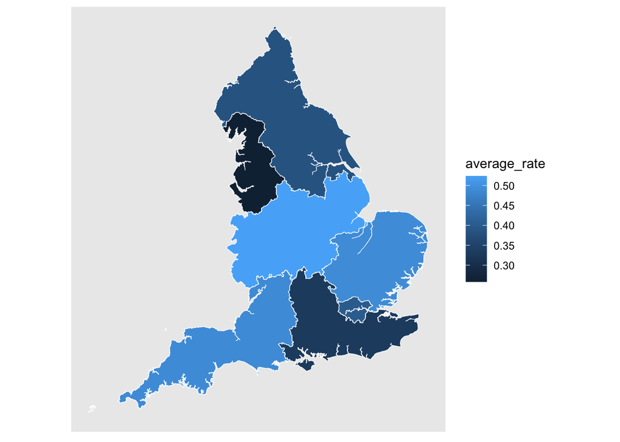

```r
choropleth <- ggplot(plot_data, aes(fill = average_rate)) +
    geom_sf(color = "#ffffff", size = 0.1) +
    theme(
      panel.grid.major = element_blank(),
      panel.grid.minor = element_blank(),
      panel.border = element_blank(),
      axis.text.y=element_blank(),
      axis.text.x=element_blank(),
      axis.ticks=element_blank(),
    )
choropleth
```

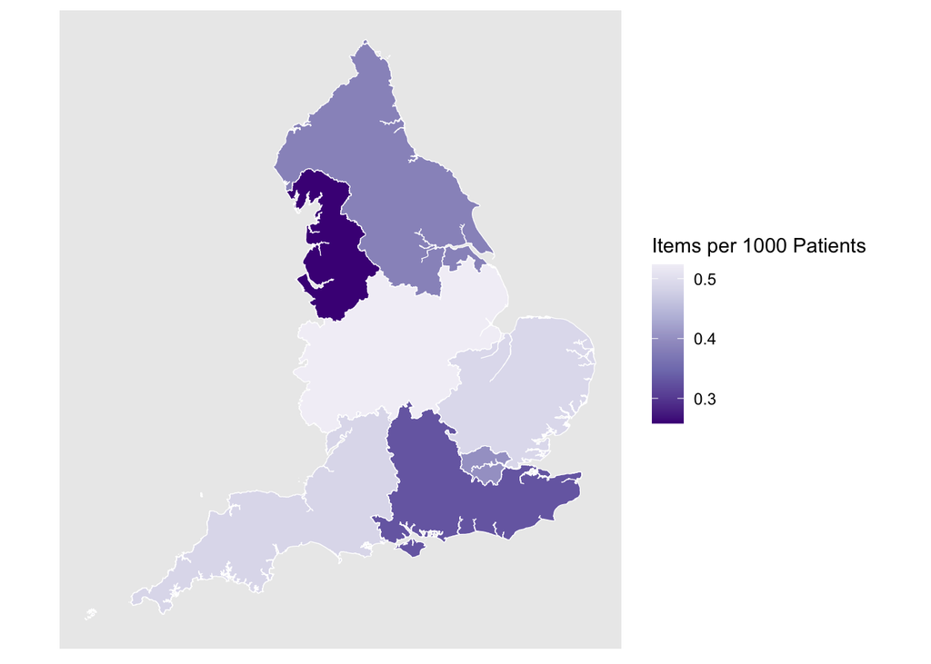

```r
choropleth <- ggplot(plot_data, aes(fill = average_rate)) +
  # creates a white border around the regions with a thickness of 0.1
    geom_sf(color = "#ffffff", size = 0.1) +
    scale_fill_distiller(name="Items per 1000 Patients", palette = "Purples", direction = -1, breaks = c(0.3, 0.4, 0.5)) +
    theme(
      panel.grid.major = element_blank(),
      panel.grid.minor = element_blank(),
      panel.border = element_blank(),
      axis.text.y=element_blank(),
      axis.text.x=element_blank(),
      axis.ticks=element_blank(),
    )
choropleth
```

Final plot with styling:

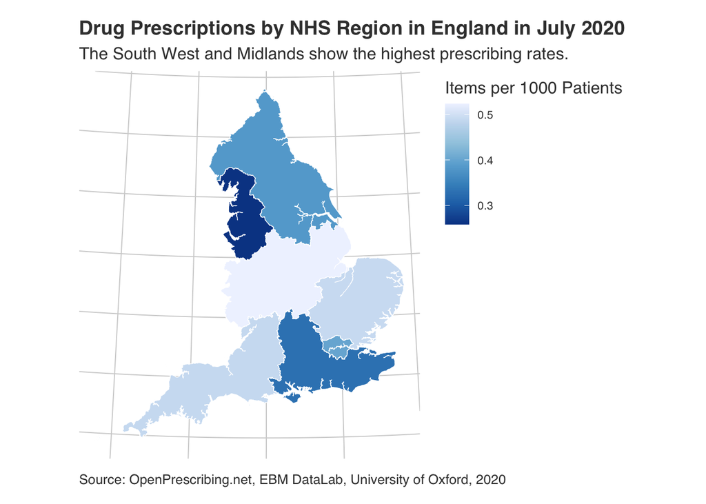

```r
choropleth2 <- ggplot(plot_data, aes(fill = average_rate)) +
  # creates a white border around the regions with a thickness of 0.1
    geom_sf(color = "#ffffff", size = 0.1) +
    scale_fill_distiller(name="Items per 1000 Patients", palette = "Blues", direction = -1, breaks = c(0.3, 0.4, 0.5)) +
    theme_fivethirtyeight() +
    theme(legend.position = "right",
        legend.justification = c("right", "top"),
        legend.text = element_text(size = 8),
        plot.title = element_text(size=14),
        axis.text=element_blank(),
        axis.title = element_blank(),
        legend.direction = "vertical",
        plot.caption = element_text(hjust = 0, vjust = 0),
        plot.background = element_rect(fill = "white", colour = "white"),
        panel.background = element_rect(fill = "white", colour = "white"),
        legend.background = element_rect(fill = "white", colour = "white"),
        panel.grid.major.x = element_blank()) +
  labs(title = "Drug Prescriptions by NHS Region in England in July 2020",
       subtitle = 'The South West and Midlands show the highest prescribing rates.' ,
       x = element_blank(),
       caption = "Source: OpenPrescribing.net, EBM DataLab, University of Oxford, 2020")

choropleth2
```

```r
ggsave(plot = choropleth2, 'prescriptions_choropleth.png', width = 8, height = 10, units = "in")
```

### Important Design Considerations

1. Colour schemes are best when they feature one colour and have different shades of that colour, or are a gradient between two coolours. Beware of ‘rainbow’ colour schemes that are hard to interpret.
2. Research has shown that when looking at a plot, the human eye is drawn to text first. Always include a title, axis labels, and a caption with the data source. If you want to make a specific comment about the plot, you could add this as a subtitle.
3. When choosing sizing, save the image in your desired first. Make sure the text on the plot is no smaller than the text in the document that the figure is going into.
4. You can make any kind of styling adjustments to the plot as you want and all of these are available through a quick Google search. As a starting point, you can use the built in ggthemes package to select a pre-built theme.

### Maps to Create

1. Show the homeless GP surgeries as points on the map.
2. Produce choropleth maps for the overall prescribing rates by region and the regional differences in the subgroups. (NOTE: as you have calculated the prescribing rates of homeless and non-homeless GP separately, you will have to combine these into one dataset.)

Remember: save each sheet to a CSV to load into R.